# Data Tidying

Data Tidying

Autor:in

Zugehörigkeit

Daniela Palleschi

Humboldt-Universität zu Berlin

Veröffentlichungsdatum

13. Dezember 2023

# Learning objectives

Today we will learn…

- about wide versus long data
- how to make wide data longer
- how to make long data wider

## Resources

The suggested resources for this topic are

- [Chapter 6 (Data tidying)](https://r4ds.hadley.nz/data-tidy) in Wickham et al. (2023)
- [Chapter 8 (Data tidying)](https://psyteachr.github.io/ads-v2/08-tidy.html) in Nordmann & DeBruine (2022)

# 1 Set-up

## 1.1 Packages

```r
pacman::p_load(tidyverse,
               here,
               janitor)
```

## 1.2 Data

- we’ll use the `languageR_english.csv` dataset (in `daten` folder)

```r
df_eng <- read_csv(here("daten", "languageR_english.csv")) |>
  clean_names() |>
  arrange(word) |>
  rename(
    rt_lexdec = r_tlexdec,
    rt_naming = r_tnaming
  )
```

**1**

Clean (i.e., *tidy*) variable names (from `janitor`)

**2**

Arrange rows by `word` in assending order (A-Z)

**3**

Rename variables…

**4**

`r_tlexdec` to `rt_lexdec`

# 2 Tidy workflow

- Abbildung 1 shows an overview of the typical data science process
  - import our data, tidy it, then work through a cycle of transforming, visualising, and modelling before finally communicating your findings

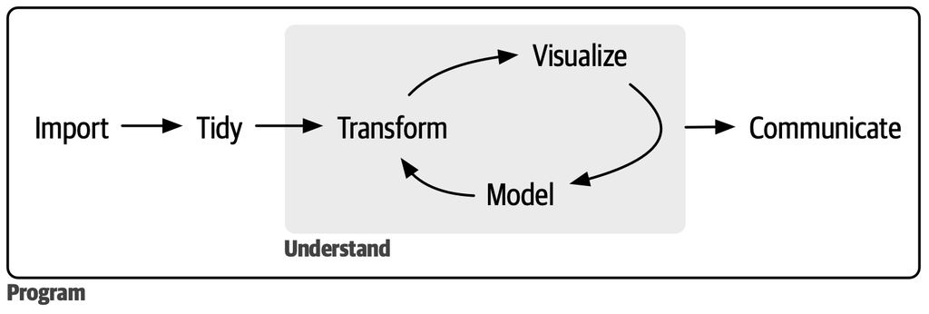

Abbildung 1: [Image source:](https://r4ds.hadley.nz/intro.html) Wickham et al. (2023) (all rights reserved)

- so far we’ve learned how to
  - import our data (`readr::read_csv`)
  - transform data (`dplyr` package)
  - visualise data (`ggplot` package)
  - communicate our findings with dynamic reports (Quarto)
- but we’ve only seen tidy data so far
  - so we haven’t needed to perform the ‘tidy’ step (`tidyr` package)

# 3 Tidy data

- the same data can be representing multiple ways
- we’re going to look at 3 tables that present the exact same data in different formats
- the tables show the same values of four variables:
  - `country`
  - `year`
  - `population`
  - and number of tuberculosis `cases`
- Each dataset organises the values differently
- As we look at each table, take a moment to consider how easy it is to understand the values and relationships between the variables

Tabelle 1: Tabelle 1

| country | year | cases | population |
| --- | --- | --- | --- |
| Afghanistan | 1999 | 745 | 19987071 |
| Afghanistan | 2000 | 2666 | 20595360 |
| Brazil | 1999 | 37737 | 172006362 |
| Brazil | 2000 | 80488 | 174504898 |
| China | 1999 | 212258 | 1272915272 |
| China | 2000 | 213766 | 1280428583 |

Tabelle 2: Tabelle 2

| country | year | type | count |
| --- | --- | --- | --- |
| Afghanistan | 1999 | cases | 745 |
| Afghanistan | 1999 | population | 19987071 |
| Afghanistan | 2000 | cases | 2666 |
| Afghanistan | 2000 | population | 20595360 |
| Brazil | 1999 | cases | 37737 |
| Brazil | 1999 | population | 172006362 |
| Brazil | 2000 | cases | 80488 |
| Brazil | 2000 | population | 174504898 |
| China | 1999 | cases | 212258 |
| China | 1999 | population | 1272915272 |
| China | 2000 | cases | 213766 |
| China | 2000 | population | 1280428583 |

Tabelle 3: Tabelle 3

| country | year | rate |
| --- | --- | --- |
| Afghanistan | 1999 | 745/19987071 |
| Afghanistan | 2000 | 2666/20595360 |
| Brazil | 1999 | 37737/172006362 |
| Brazil | 2000 | 80488/174504898 |
| China | 1999 | 212258/1272915272 |
| China | 2000 | 213766/1280428583 |

## 3.1 Rules for tidy data

- You likely found Tabelle 1 easiest to read
  - it follows the three rules for tidy data (visualised in Abbildung 2):
1. Each variable is a column, each column is a variable
2. Each observation is a row, each row is an observation
3. Each value is a cell, each cell is a single value

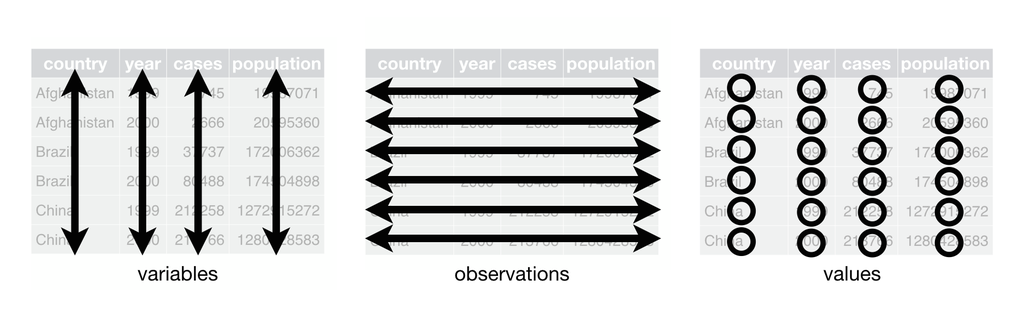

Abbildung 2: [Image source:](https://r4ds.hadley.nz/data-tidy.html) Wickham et al. (2023) (all rights reserved)

## 3.2 Why tidy data?

> “**Happy families** are all alike; every **unhappy family** is unhappy in its own way.” — Leo Tolstoy

> “**Tidy datasets** are all alike, but every **untidy dataset** is untidy in its own way.” — Hadley Wickham

There are two main advantages to working with tidy data:

1. working with a consistent data structure allows us to adopt conventions
   - since tidy data is the generally agreed upon data structure, conventions are built on the assumption of this structure
   - so tools have an underlying uniformity
2. `R`’s vectorised nature can shine
   - most built-in R funtions work with *vector values* (and columns are essentially vectors)
   - all packages in the `tidyverse` are designed to work with tidy data (e.g., `ggplot2` and `dplyr`)

**Aufgabe 1: Tidy data**

**Beispiel 1**

1. Go back to Tables 1-3. For each table, describe what each observation and each column represents.
2. Sketch out the process you’d use to calculate the rate for Tabelle 1. You will need just one verb that:
   - creates a new variable (call it `rate`) that contains:
     - the number of TB `cases` per country per year, divided by
     - the matching `population` per country per year,
     - multiply by `10000`
   - hint: Which `dplyr` verb creates new variables? (Look back at **?@sec-data-transform**.)
3. Look at tables 2 and 3. Would it have been as easy to calculate `rate` with these data structures?

# 4 Data tidying

- transforming wide data to long data and long data to wide data (among other steps)
  - outcome: tidy data (usually)

## 4.1 Data tidying with the `tidyverse`

- `tidyr` package (from the `tidyverse`) has two useful functions for transposing our data:
  - `pivot_longer()`: make wide data longer
  - `pivot_wider()`: make long data wider

[figure not shown]

Abbildung 3: die berühmteste Verwendung des Wortes Pivot (zumindest für Millenials) ([Friends](https://www.youtube.com/watch?v=8w3wmQAMoxQ))

## 4.2 Wide versus long data

- we often need to convert between wide and long data formats to do different types of summaries or visualisation
- wide data: all of the observations about one thing are in the same row
  - is *usually* not tidy
- long data: each observation is on a separate row
  - is *usually* tidy
- let’s start with the most typical case: turning wide data into long data

# 5 `pivot_longer()`

- in the `languageR_english.csv` dataset (`df_eng`)
  - we have 4568 observations (rows)
  - we have 7 variables (columns)
  - the column `age_subject` tells us whether an observation is from a participant in the ‘old’ or ‘young’ age group
  - the columns `word`, `length_in_letters`, `written_frequency`, and `word_category` describe properties of the stimulus for a given observation (i.e., the word)
  - the column `rt_lexdec` contains the response time for a lexical decision task
  - the column `rt_naming` contains the response time for a word naming task

Tabelle 4: df_eng

| age_subject | word | length_in_letters | written_frequency | word_category | rt_lexdec | rt_naming |
| --- | --- | --- | --- | --- | --- | --- |
| young | ace | 3 | 4.219508 | N | 623.61 | 456.3 |
| old | ace | 3 | 4.219508 | N | 775.67 | 607.8 |
| young | act | 3 | 8.118207 | V | 617.10 | 445.8 |
| old | act | 3 | 8.118207 | V | 715.52 | 639.7 |
| young | add | 3 | 7.319203 | V | 575.70 | 467.8 |
| old | add | 3 | 7.319203 | V | 742.19 | 605.4 |

- is this data in Tabelle 4 tidy?
- is this data too wide or too long?
- how might we make this data longer?

## 5.1 Our goal

- we want to produce Abbildung 4

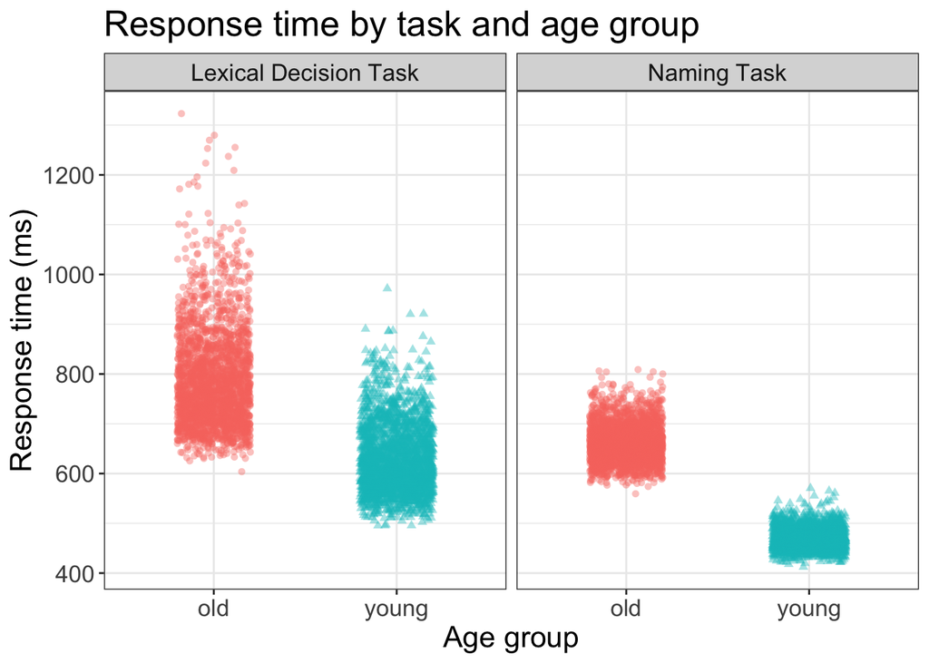

Abbildung 4: Our plot to be reproduced

- the two continuous variables `rt_lexdec` and `rt_naming` appear in facets
  - `facet_wrap()` takes a *categorical* variable as its argument, and produces a facet of each category
- so we need a categorical variable which contains the levels `lexdec` and `naming`
  - and a *continuous* variable that contains the corresponding response time

## 5.2 `pivot_longer()`

- `tidyr` function `pivot_longer()` converts a wide data table to a longer format
  - converts the names of specified columns into the values of new a categorical column
  - and combines the values of those columns into a new column

```r
df_eng_long <-
  df_eng %>%
  pivot_longer(
    cols = starts_with("rt_"),
    names_to = "response",
    values_to = "time"
  )
```

**1**

Create a new object called `df_eng_long`, which contains…

**2**

`df_eng`, and then

**3**

make it longer

**4**

by taking columns that start with `rt_`

**5**

and create a variable called `response` that contains the names from `cols`

**6**

and create a variable called `time` that contains the values from `cols`

- look at the output

```r
df_eng_long |> head()
```

```
# A tibble: 6 × 7
  age_subject word  length_in_letters written_frequency word_category response
  <chr>       <chr>             <dbl>             <dbl> <chr>         <chr>
1 young       ace                   3              4.22 N             rt_lexdec
2 young       ace                   3              4.22 N             rt_naming
3 old         ace                   3              4.22 N             rt_lexdec
4 old         ace                   3              4.22 N             rt_naming
5 young       act                   3              8.12 V             rt_lexdec
6 young       act                   3              8.12 V             rt_naming
# ℹ 1 more variable: time <dbl>
```

- let’s compare the observations for the words `ace` and `act` in
  - `df_eng` (Tabelle 5) +`df_eng_longer` (Tabelle 6)

Tabelle 5: `df_eng`

| age_subject | word | rt_lexdec | rt_naming |
| --- | --- | --- | --- |
| young | ace | 623.61 | 456.3 |
| old | ace | 775.67 | 607.8 |
| young | act | 617.10 | 445.8 |
| old | act | 715.52 | 639.7 |

Tabelle 6: `df_eng |> pivot_longer(...)`

| age_subject | word | response | time |
| --- | --- | --- | --- |
| young | ace | rt_lexdec | 623.61 |
| young | ace | rt_naming | 456.30 |
| old | ace | rt_lexdec | 775.67 |
| old | ace | rt_naming | 607.80 |
| young | act | rt_lexdec | 617.10 |
| young | act | rt_naming | 445.80 |
| old | act | rt_lexdec | 715.52 |
| old | act | rt_naming | 639.70 |

- the two tables contain the exact same information
  - 8 response time values:
    - 4 for `rt_lexdec`
    - 4 for `rt_naming`
- this is an important realisation: we haven’t changed any data or observation values, we’ve just simply re-structured the organisation of the data points

### 5.2.1 Plotting our tidy data

- now let’s try to create our plot:
  - `age_subject` on the x-axis
  - `time` on the y-axis
  - `response` categories in facets

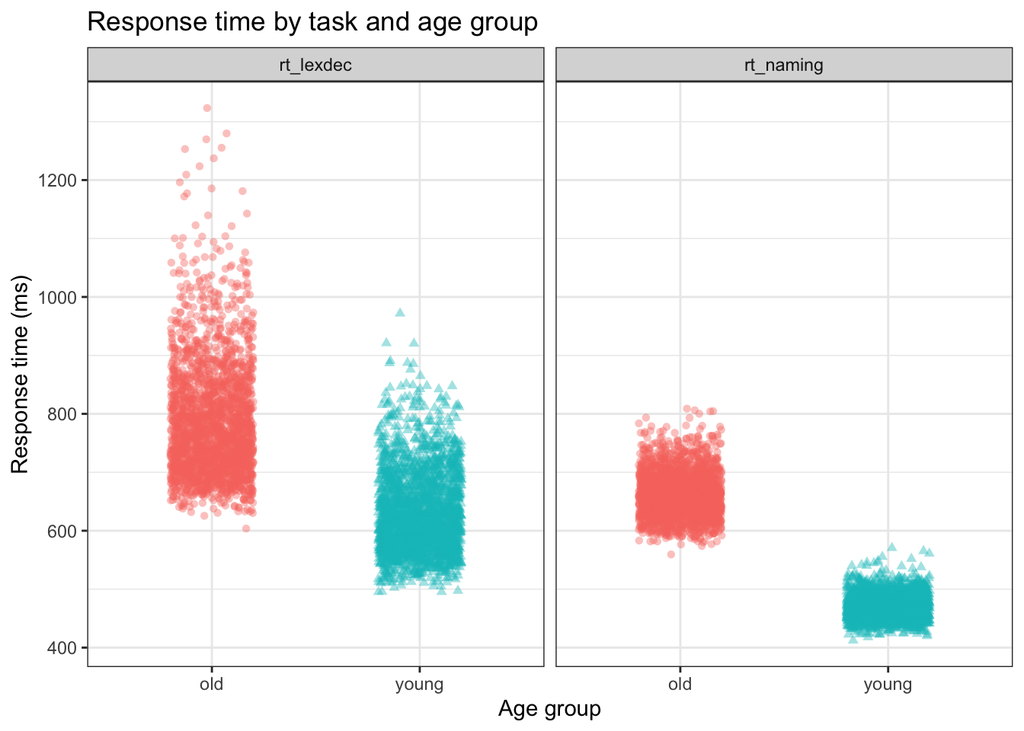

Abbildung 5: Response times per age group for the lexical decision task vs. naming task

**Aufgabe 1: Tidy data**

**Beispiel 2**

Recreate Abbildung 5

# 6 `pivot_wider()`

- it’s more common to want to lengthen your data (take columns and turn their values into new rows)
  - but sometimes we also want to widen our data (take rows and turn their values into new columns)
- `tidyr` function `pivot_wider()` make datasets *wider* by increasing columns and reducing rows
  - this helps when one observation is spread across multiple rows
- let’s try to make `df_eng` wider
  - for example, we could have a single row per *word*
    - with a single variable for the `young` subject’s response and the `old` subject’s response

## 6.1 `pivot_wider()`

- pivot wider takes similar arguments to `pivot_longer()`, with some slight differences:
  - `id_cols` (optional): identifying columns (which columns uniquely identify each observation?)
  - `names_from`: what should we call the new column containing the previous column names (must be a categorical variable)?
  - `names_prefix` (optional): prefix for the new column names (optional)
  - `values_from`: new column values

Let’s create two new variables that take their names from `age_subject`, and their values from `rt_lexdec`. The result should look like Tabelle 8.

```r
df_eng_wide <-
  df_eng %>%
  select(-rt_naming) |>
  pivot_wider(
    names_from = age_subject,
    values_from = rt_lexdec,
    names_prefix = "lexdec_"
  )
```

**1**

create new column names using the values in `age_subject`

**2**

create new observation values from `rt_lexdec`

**3**

add `lexdec_` to the beginning of the new column names

Tabelle 7: `df_eng`

| age_subject | word | length_in_letters | written_frequency | word_category | rt_lexdec |
| --- | --- | --- | --- | --- | --- |
| young | ace | 3 | 4.219508 | N | 623.61 |
| old | ace | 3 | 4.219508 | N | 775.67 |
| young | act | 3 | 8.118207 | V | 617.10 |
| old | act | 3 | 8.118207 | V | 715.52 |

Tabelle 8: Wider `df_eng` data

| word | length_in_letters | written_frequency | word_category | lexdec_young | lexdec_old |
| --- | --- | --- | --- | --- | --- |
| ace | 3 | 4.219508 | N | 623.61 | 775.67 |
| act | 3 | 8.118207 | V | 617.10 | 715.52 |

- the two tables contain the exact same information
  - 4 lexical decision response time values:
    - 2 for `old` (1 per word)
    - 2 for `young` (1 per word)
- again, we haven’t changed any data or observation values, we’ve just simply re-structured the organisation of the data points

**Unique values**

Tabelle 9: Wider `df_eng` data with NA’s

| word | length_in_letters | written_frequency | word_category | rt_naming | lexdec_young | lexdec_old |
| --- | --- | --- | --- | --- | --- | --- |
| ace | 3 | 4.219508 | N | 456.3 | 623.61 | NA |
| ace | 3 | 4.219508 | N | 607.8 | NA | 775.67 |
| act | 3 | 8.118207 | V | 445.8 | 617.10 | NA |
| act | 3 | 8.118207 | V | 639.7 | NA | 715.52 |

# Learning objectives 🏁

Today we learned…

- about wide versus long data ✅
- how to make wide data longer ✅
- how to make long data wider ✅

# 7 Homework

We’ll stick with the `df_eng` dataset for these tasks.

1. Using `pivot_wider` to create `rt_naming` new variables: `naming_old` and `naming_young` which containg the naming response times for old and young participants, respectively. Hint: you will need to remove `rt_lexdec`. The resulting data frame should have 2284 observations and 6 variables.
2. Recreate Abbildung 6. Hint: you will need `pivot_wider()`.

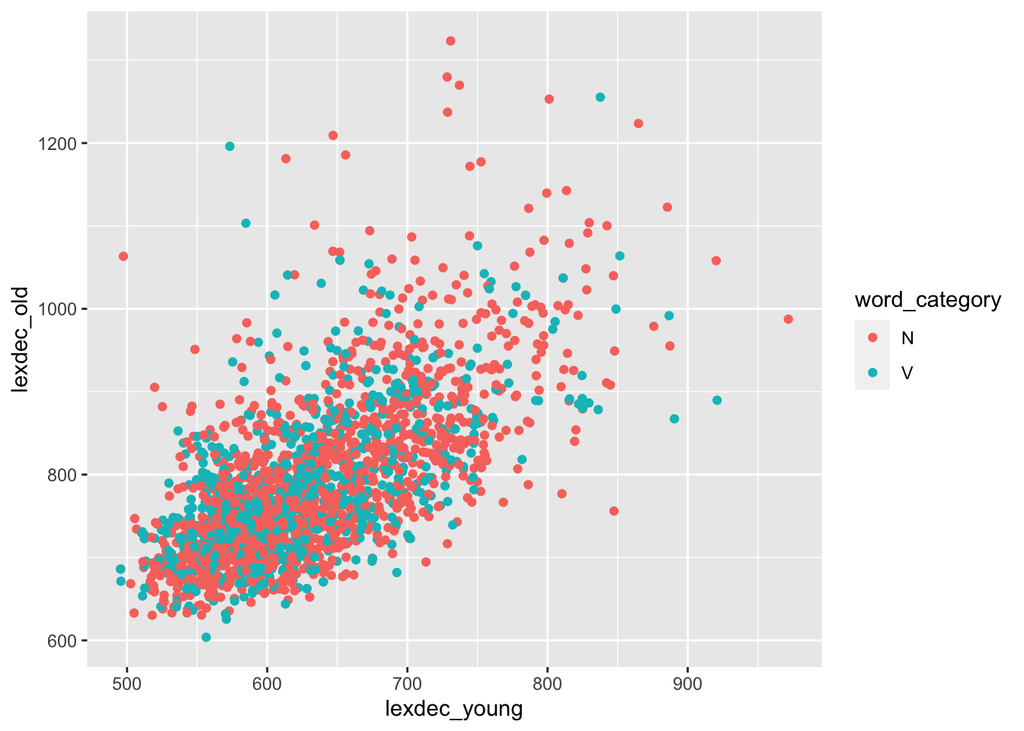

Abbildung 6: Scatterplot of lexical decision task response times per word for old versus young participants

3. Why do we need out `df_eng_wide` dataset to produce Abbildung 6? In other words, why is `df_eng_wide` the appropriate structure but not `df_eng_long` for such a scatterplot?
4. Using `df_eng_long` and the `summarise()` function we saw in the last section, reproduce the summary below:

```
# A tibble: 2 × 3
  response   mean    sd
  <chr>     <dbl> <dbl>
1 rt_lexdec  708.  115.
2 rt_naming  566.  101.
```

Hint: do you need to remove `NA`s (we saw how to do this in the last section)?

# Session Info

Hergestellt mit R version 4.3.0 (2023-04-21) (Already Tomorrow) und RStudioversion 2023.9.0.463 (Desert Sunflower).

# Literaturverzeichnis

Nordmann, E., & DeBruine, L. (2022). *Applied Data Skills*. Zenodo. https://doi.org/10.5281/zenodo.6365078

Wickham, H., Çetinkaya-Rundel, M., & Grolemund, G. (2023). *R for Data Science* (2. Aufl.).